# Análisis de datos de Bellabeat!

Sergio Molina Flores

2024-12-19

## INTRODUCCION

La empresa BellaBeat, solicita que, mediante datos externos de uso de dispositivos inteligentes, se puedan analizar y profundizar para resolver las siguientes preguntas:

- ¿Cuáles son algunas tendencias de uso de los dispositivos inteligentes?
- ¿Cómo se podrían aplicar estas tendencias a los clientes de Bellabeat?
- ¿Cómo podrían ayudar estas tendencias a influir en la estrategia de marketing de Bellabeat?

## DATOS

Los datos utilizados para este analisis son de uso publico, y esta disponbibles en el siguien sitio web (https://www.kaggle.com/datasets/arashnic/fitbit), estos datos en resumen muestran distintos usos de los usuarios que en total para este analisis fueron 35.

## ANALISIS POR MEDICION DE ACTIVIDADES MENSUALES

### DATOS DE MEDICION DE ACTIVIDADES DIARIAS MENSUALES

```
##       Mes             Conexiones_unicas
##  Min.   :2016-03-01   Min.   :11.00
##  1st Qu.:2016-03-16   1st Qu.:20.50
##  Median :2016-04-01   Median :30.00
##  Mean   :2016-03-31   Mean   :25.33
##  3rd Qu.:2016-04-16   3rd Qu.:32.50
##  Max.   :2016-05-01   Max.   :35.00
```

### GRAFICOS MEDICIONES DE ACTIVIDADES DIARIAS MENSUALES

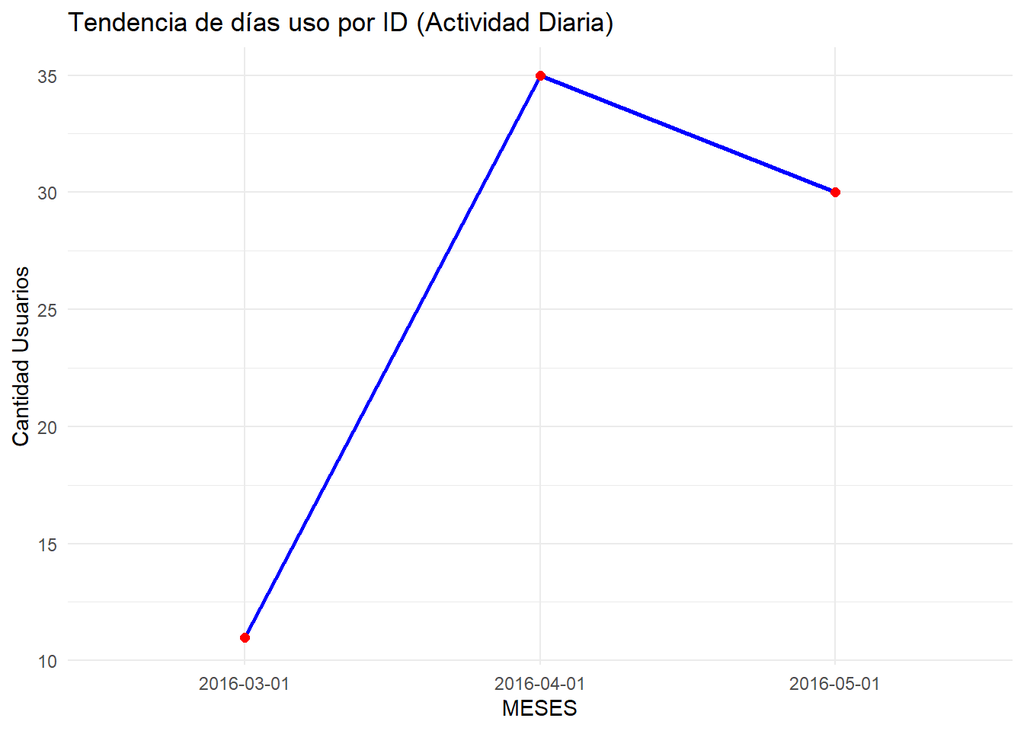

## ANALISIS POR MEDICION DE CALORIAS MENSUALES

### DATOS DE MEDICION DE CALORIAS MENSUALES

```
##        Id            Total_Dias_Usados     Id_num
##  Min.   :1.504e+09   Min.   : 1.00     Min.   : 1.0
##  1st Qu.:2.610e+09   1st Qu.:56.00     1st Qu.: 9.5
##  Median :4.445e+09   Median :61.00     Median :18.0
##  Mean   :4.845e+09   Mean   :55.29     Mean   :18.0
##  3rd Qu.:6.869e+09   3rd Qu.:62.00     3rd Qu.:26.5
##  Max.   :8.878e+09   Max.   :62.00     Max.   :35.0
```

### GRAFICOS DE MEDICION DE CALORIAS MENSUALES

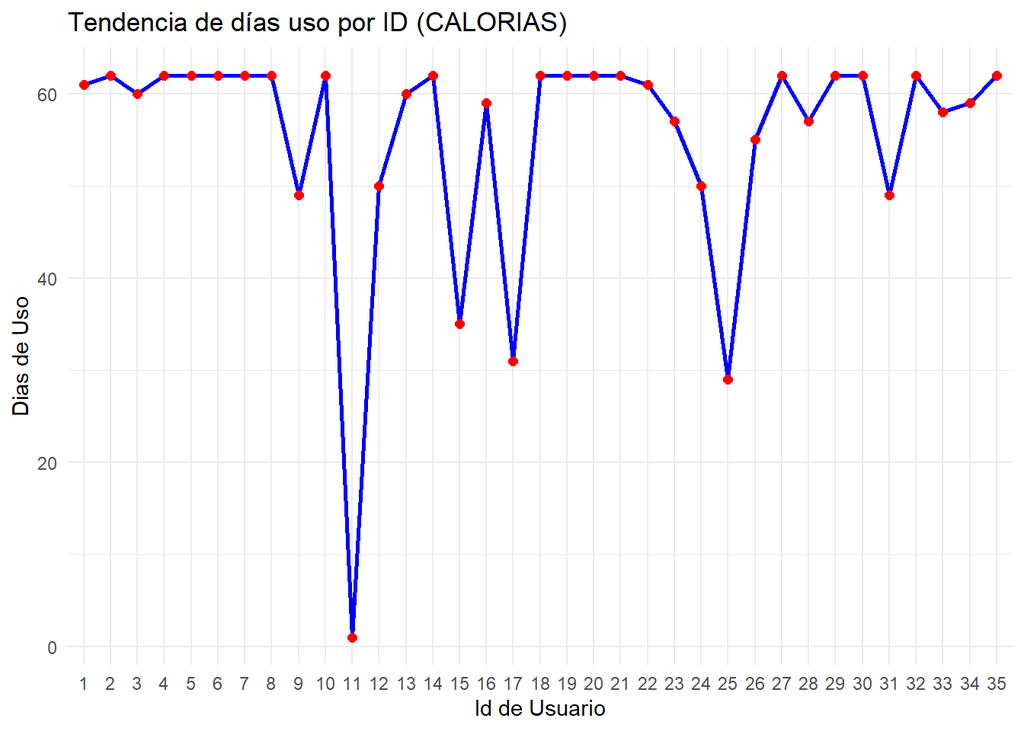

## ANALISIS POR MEDICION DE INTENSIDAD DIARIAS

### DATOS DE MEDICION DE INTENSIDAD DIARIAS

```
##        Id            Total_Dias_Usados     Id_num
##  Min.   :1.504e+09   Min.   : 1.00     Min.   : 1.0
##  1st Qu.:2.610e+09   1st Qu.:56.00     1st Qu.: 9.5
##  Median :4.445e+09   Median :61.00     Median :18.0
##  Mean   :4.845e+09   Mean   :55.29     Mean   :18.0
##  3rd Qu.:6.869e+09   3rd Qu.:62.00     3rd Qu.:26.5
##  Max.   :8.878e+09   Max.   :62.00     Max.   :35.0
```

### GRAFICOS MEDICIONES DE INTENSIDAD DIARIAS

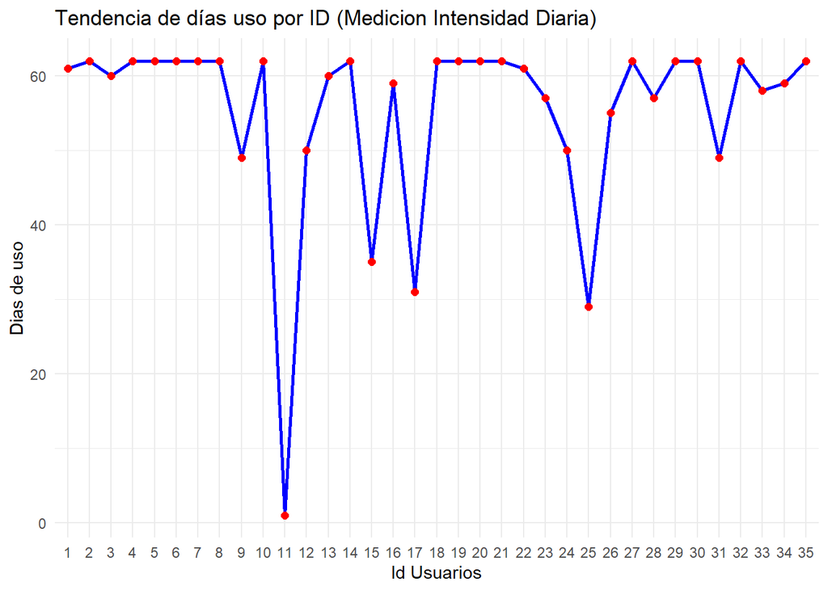

## ANALISIS POR MEDICION DE METAS DIARIAS

### DATOS DE MEDICION DE METAS DIARIAS

```
##        Id            Total_Dias_Usados     Id_num
##  Min.   :1.504e+09   Min.   : 1.00     Min.   : 1.0
##  1st Qu.:2.610e+09   1st Qu.:56.00     1st Qu.: 9.5
##  Median :4.445e+09   Median :61.00     Median :18.0
##  Mean   :4.845e+09   Mean   :55.29     Mean   :18.0
##  3rd Qu.:6.869e+09   3rd Qu.:62.00     3rd Qu.:26.5
##  Max.   :8.878e+09   Max.   :62.00     Max.   :35.0
```

### GRAFICOS MEDICIONES DE METAS DIARIAS

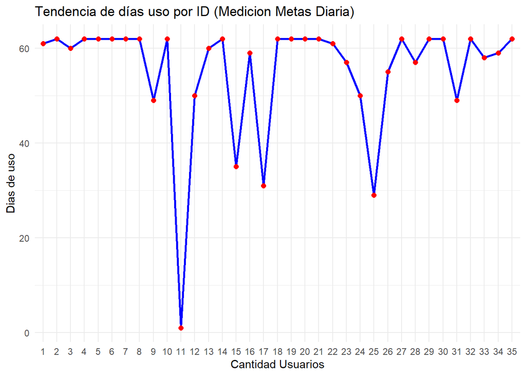

## ANALISIS POR MEDICION DE PASOS DIARIOS

### DATOS DE MEDICION DE PASOS DIARIOS

```
##        Id            Total_Dias_Usados     Id_num
##  Min.   :1.504e+09   Min.   : 1.00     Min.   : 1.0
##  1st Qu.:2.610e+09   1st Qu.:56.00     1st Qu.: 9.5
##  Median :4.445e+09   Median :61.00     Median :18.0
##  Mean   :4.845e+09   Mean   :55.29     Mean   :18.0
##  3rd Qu.:6.869e+09   3rd Qu.:62.00     3rd Qu.:26.5
##  Max.   :8.878e+09   Max.   :62.00     Max.   :35.0
```

### GRAFICOS MEDICIONES DE PASOS DIARIAS

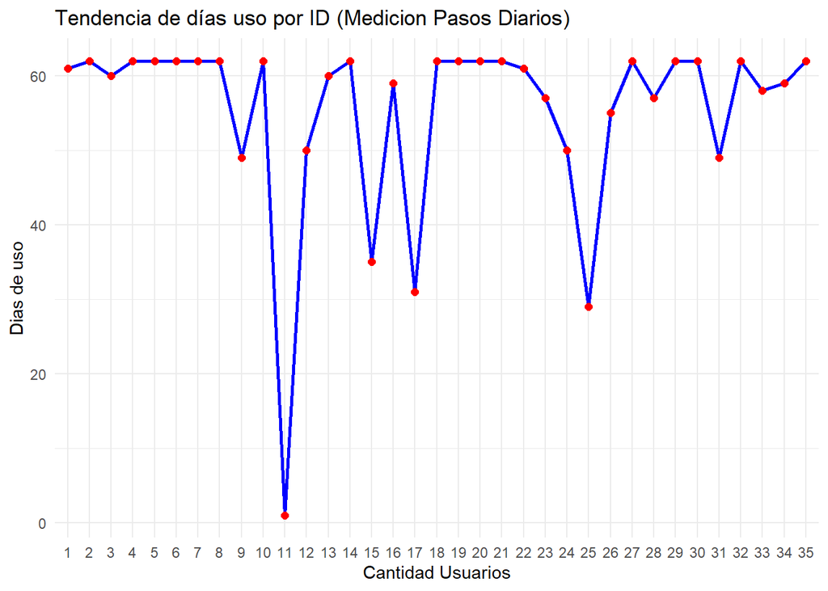

## ANALISIS POR MEDICION DE SUEÑO DIARIOS

### DATOS DE MEDICION DE SUEÑO DIARIOS

```
##        Id            Total_Dias_Usados     Id_num
##  Min.   :1.504e+09   Min.   : 1.00     Min.   : 1
##  1st Qu.:2.320e+09   1st Qu.:12.00     1st Qu.: 7
##  Median :4.445e+09   Median :44.00     Median :13
##  Mean   :4.654e+09   Mean   :36.04     Mean   :13
##  3rd Qu.:6.776e+09   3rd Qu.:57.00     3rd Qu.:19
##  Max.   :8.792e+09   Max.   :63.00     Max.   :25
```

### GRAFICOS MEDICIONES DE SUEÑO DIARIAS

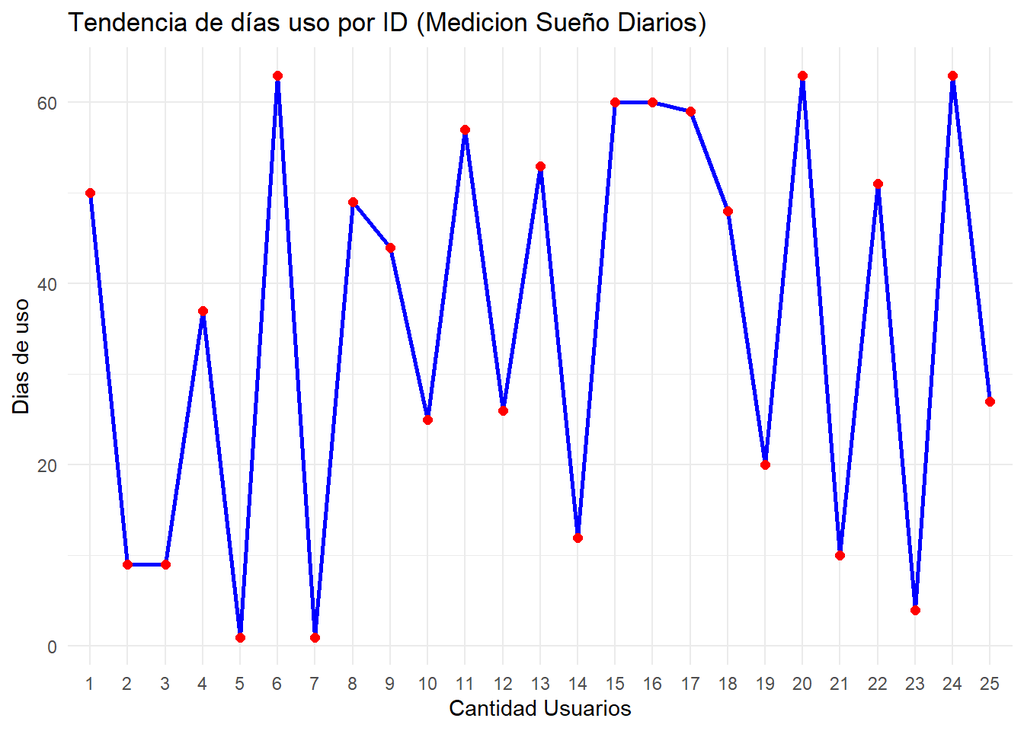

## ANALISIS POR MEDICION DE FRECUENCIA CARDIACA DIARIA

### DATOS DE MEDICION DE FRECUENCIA CARDIACA DIARIA

```
##        Id            Total_Dias_Usados     Id_num
##  Min.   :2.022e+09   Min.   : 3.00     Min.   : 1.0
##  1st Qu.:4.204e+09   1st Qu.:28.00     1st Qu.: 4.5
##  Median :5.577e+09   Median :32.00     Median : 8.0
##  Mean   :5.428e+09   Mean   :31.27     Mean   : 8.0
##  3rd Qu.:6.869e+09   3rd Qu.:42.00     3rd Qu.:11.5
##  Max.   :8.878e+09   Max.   :44.00     Max.   :15.0
```

### GRAFICOS MEDICIONES DE FRECUENCIAS DIARIAS

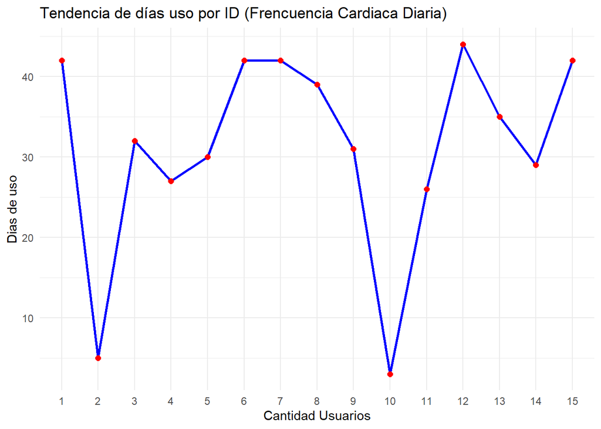

## ANALISIS POR MEDICION DE PESO DIARIO

### DATOS DE MEDICION DE PESO DIARIO

```
##        Id            Total_Dias_Usados     Id_num
##  Min.   :1.504e+09   Min.   : 1.000    Min.   : 1
##  1st Qu.:2.873e+09   1st Qu.: 1.000    1st Qu.: 4
##  Median :4.445e+09   Median : 2.000    Median : 7
##  Mean   :4.557e+09   Mean   : 7.538    Mean   : 7
##  3rd Qu.:5.577e+09   3rd Qu.: 4.000    3rd Qu.:10
##  Max.   :8.878e+09   Max.   :43.000    Max.   :13
```

### GRAFICOS MEDICIONES DE PESO DIARIO

[figure not shown]

## CONCLUSION

Segun los antecedentes antes expuestos, se puede concluir que un total de 35 usuarios realizaron mediciones regulares en cuanto ha medicion de actividad diarias, calorias, intensidad, meta, pasos; que un total de 25 usuarios realizaron mediciones de sueño y que un total de 13 usuarios realizaron mediciones de peso. Dentro de las mediciones que se realizaron con mayor frecuencia fueron: Calorias, intensidad, metas, pasos, llegando a un total de 89,2% de dias promedio de uso. Dentro de las mediciones que se realizaron en menor frecuencia fueron: sueño con un total de 57,2% de dias promedio de uso (36 dias), frecuencia cardiaca con un total de 51% de dias promedio de uso(31 dias) y peso con un total de 12,1% de dias promedio de uso (8 dias).

## RECOMENDACIONES

De lo anterior mencionado, es que para la empresa BellaBeat lo mas importante y lo que deberia considerar para su proyeccion, es centrarlizar su esfuerzos en apliaciones que midan, actvidad diaria, calorias, intensidad, metas, pasos y de igual forma considerar medir sueño pero que tendra menos implicancia, debido al menor uso. No resultaria util centrar los esfuerzos en apliaciones de frecuencia cardiaca ni tampoco de peso, por que segun la tendencia, estos tendria una menor utilizacion.